**Trial biostatistics toolkit**

OperationsBiostatisticsFull library

# Find Hours, Budget Reconciliation (effort only)

A visual, runnable guide, from the biostatistics lens

**Run / share / skim / file / build, pick your mode.** This page *shows* the reconciliation (diagrams + a live roll-up computed from the ledger), the **runnable R Shiny app** lets you *run* one interactively, the dashboard is a shareable snapshot, the one-pager is the skim, the Excel workbook is what you file, and the build-it walkthrough shows how the app is made. Operations-only, synthetic, hours / effort only (no dollars, rates, or headcount).

## The whole idea, in one line

When a new out-of-scope ask lands, you do not immediately ask for more. First you find the hours you already have: honest under-run slack across the tasks that are tracking under plan, plus the management reserve. Only the residual becomes a change order.

**Net findable** = (∑ Planned + Contingency) − ∑ EAC

Under-run slack is the positive difference between total planned effort and total estimate-at-completion (EAC). Existing forecast overruns consume contingency first. Net headroom is signed: a negative value is an existing deficit, not available capacity. For example, 850 h planned + 40 h reserve − 900 h EAC = −10 h; a new 45 h ask then leaves a total 55 h gap (10 h existing plus 45 h new).

## What to do with a new ask, the decision tree

```
flowchart LR
  accTitle: Find-hours decision tree
  accDescr: A new ask is covered first from under-run slack, then from contingency, then by deferring or re-sequencing planned work; whatever remains becomes a change order, and the rest is absorbed internally.
  ASK["New ask,<br/>estimate effort"] --> SLACK{"Slack<br/>covers it?"}
  SLACK -->|Yes| REALLOC["Reallocate<br/>under-run slack"]
  SLACK -->|"Partly / No"| CONT{"Contingency<br/>covers rest?"}
  CONT -->|Yes| DRAW["Draw reserve,<br/>log it"]
  CONT -->|"Partly / No"| DEFER{"Defer /<br/>re-sequence?"}
  DEFER -->|Yes| RESEQ["Free planned<br/>hours"]
  DEFER -->|No| CO["Change order,<br/>the residual"]
  REALLOC --> ABS["Absorbed<br/>internally"]
  DRAW --> ABS
  RESEQ --> ABS
```

The tool sources a new ask from net under-run slack, then the reserve remaining after existing forecast overruns. It reports the unfunded new ask and any existing deficit separately. Deferring, re-sequencing, and contractual treatment require a human decision; an overrun does not itself establish added scope.

## Where every number comes from, the source map

The ledger you see below is a *picture* built from synthetic data. On a real study each column is fed from a system of record, and the tool never invents a number.

```
flowchart LR
  accTitle: Where the ledger data come from
  accDescr: Planned hours from the SOW and budget grid, actual hours from the timesheet system, and percent done and EAC from estimates feed the effort ledger, which rolls up to net findable hours and the change-order process.
  SOW["SOW / budget<br/>grid, CTMS"] -->|Planned| LEDG[("Effort<br/>ledger")]
  TS["Timesheet<br/>system"] -->|Actual| LEDG
  EST["Estimate +<br/>progress"] -->|"% done, EAC"| LEDG
  LEDG --> ROLL["Roll-up,<br/>net findable"]
  ROLL --> CO["Change-order<br/>process"]
```

| Column | Source of record |
| --- | --- |
| **Planned** | SOW / budget grid in CTMS |
| **Actual to date** | Timesheet system |
| **% complete, EAC** | Your estimate + the progress tracker |
| **Change order** | Contract process: lead biostatistician + PM review, sponsor sign-off, SOW amended |

The tool does not connect to CTMS or timesheets. You **transcribe** current figures into the ledger, on purpose, so the reconciliation is attributable and stands on its own. Every number here comes from the ledger file and the shared logic core, never from an assistant.

## The live roll-up, computed from the ledger

This is the same logic the Shiny app and the Excel workbook use, rendered here from the effort ledger, `project_hours_ledger.csv` (in the `templates/` folder). Edit that ledger (or run the app) and these move.

850

Planned (h)

513

Spent to date (h)

831

Forecast EAC (h)

40

Contingency (h)

59

Net findable (h)

Net findable here is 19 h of under-run slack (planned 850 − EAC 831) plus 40 h of contingency = **59 h** you can redirect before a change order.

**Planned vs forecast**

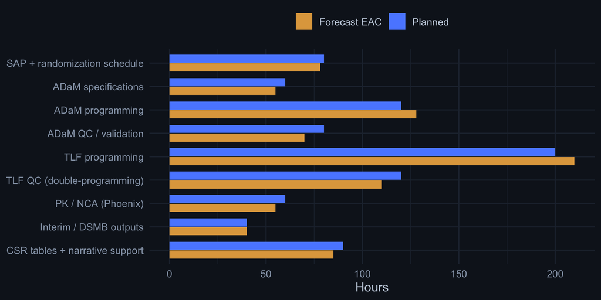

Tasks where the blue (planned) bar sits above the gold (forecast) bar are the ones giving up slack. Where gold exceeds blue, that task is over-running and is being watched, not raided.

**Effort ledger**

| Deliverable | Planned | Actual | % done | EAC | Under-run slack |
| --- | --- | --- | --- | --- | --- |
| SAP + randomization schedule | 80 | 78 | 100 | 78 | 2 |
| ADaM specifications | 60 | 55 | 100 | 55 | 5 |
| ADaM programming | 120 | 90 | 70 | 128 | 0 |
| ADaM QC / validation | 80 | 40 | 60 | 70 | 10 |
| TLF programming | 200 | 120 | 60 | 210 | 0 |
| TLF QC (double-programming) | 120 | 50 | 45 | 110 | 10 |
| PK / NCA (Phoenix) | 60 | 30 | 55 | 55 | 5 |
| Interim / DSMB outputs | 40 | 40 | 100 | 40 | 0 |
| CSR tables + narrative support | 90 | 10 | 10 | 85 | 5 |

The table shows each task’s positive under-run. Available slack uses the **net** portfolio variance, `max(0, sum(planned) − sum(EAC))`, so overruns on other tasks offset apparent savings. In this example that is 19 h.

## Testing an ask, two worked examples

**Ask 45 h, absorbable**

Ask: 45 h → Absorbable internally

19 h from under-run slack

26 h from contingency reserve

0 h residual (change order)

Contingency left after this ask: 14 h.

A 45 h ask is fully covered: 19 h from under-run slack and 26 h from contingency, no residual. It is absorbable internally with 14 h of reserve still held back.

**Ask 90 h, change order**

Ask: 90 h → Change order needed: 31 h

19 h from under-run slack

40 h from contingency reserve

31 h residual (change order)

Contingency left after this ask: 0 h.

A 90 h ask exhausts the 19 h of slack and the full 40 h of contingency, leaving a **31 h** residual. That residual is genuine new scope: it goes to the change-order process (lead biostat + PM review, sponsor sign-off, SOW amended). The tool drafts the hours-only note; pricing is handled downstream by the PM.

## Run it, and build it

The interactive tool is a real R Shiny app you own. From the package root:

```r
shiny::runApp("budget_reconciliation/shiny")
# needs: install.packages(c("shiny","bslib","DT","ggplot2"))
```

Edit a task’s EAC, change the ask, and the net-findable roll-up and verdict recompute live. Download the reconciled ledger to CSV to drop into the Excel workbook.

**You want to build these yourself.** The whole app is small: `shiny/R/logic.R` holds the reconciliation math (the functions this page also called), and `shiny/app.R` is the UI + reactivity. The build-it walkthrough takes you through it piece by piece. Change the ledger CSV to your study and it is your reconciliation.

## The other formats

| Mode | Artifact |
| --- | --- |
| Run | Run & build the Shiny app, edit EAC, test an ask, download |
| Share (no R) | Dashboard, the roll-up as a self-contained page |
| Present | Slides |
| Skim | One-page cheat-sheet (PDF) |
| File | Excel workbook, the record you keep |
| Build | Build-it walkthrough |

*Synthetic data throughout. Hours / effort only. A change order is a named-human, contracted decision; pricing is handled downstream by the PM / project finance.*